# Team_Project

David Sun, Elizabeth Morales, Jaehee Jeong Sarah Heuschele, Tyler Chun, Yolanda Jin Team Name: i need a </br>

6/1/2021

## 1) Abstract

Celiotomy, commonly referred to as “colic surgery” is a type of surgery around the abdomin of a horse. According to the American College of Vetinary Surgeons, colic surgery is used to address many issues that affect the longevity of a horse, most commonly used to address issues within the gastrointestinal tract within the intestines. The surgery is also used to address a number of other lesians around the abdominal.

## 2) Introduction

Horses are regarded as powerful and courageous animal that are highly desired for riding, ranch work, jumping, racing, or dressage. As with any animal, there are always complications that may arise in regards to their health. This is especially true in Horses. Horses can develop health problems at any stage in life and some are more susceptible to health problems than others. Our dataset focuses on horses who suffer from Colic. Colic is defined as having abdominal pains but in horses it is referred to problems in gastro-intestinal tract. Some common causes of Colic are High grain based diets/Low forage diets, Moldy/Tainted feed, Abrupt change in feed, Parasite infestation , Lack of water consumption leading to impaction colics, Sand ingestion, Long term use of NSAIDS, Stress and Dental problems. About 10% of horses die from colic which is why its important to understand variables that can contribute to their outcome given that the horse underwent Colic Surgery.

## 3) Method(s)

1. Data Collection
2. Exploratory Data Analysis

## 4) Data

Our data was sourced from the University of California, Irvine Machine Learning Repository.

This specific dataset was donated August 6, 1989 by Will Taylor. It was created for use by Mary McLeish & Matt Cecile who belong to the Department of Computer Science at the University of Guelph in Guelph, Ontario, Canada.

| **Variable Name** | **Description** |
| --- | --- |
| ID | a row indicator which uniquely identifies each row |
| surgery | was the horse treated with or without surgery |
| age | identify if the horse in an adult or a child (young identified as under |
|  | 6 months) |
| hospital_number | the case number assigned to the horse (same number if a horse is |
|  | treated twice) |
| rectal_temp | the temperature of the horse’s rectum recorded in degrees Celsius |
| pulse | a horse’s heart rate measured in beats per minute |
| respiratory_rate | the number of breaths a horse takes per minute |
| temp_of_extremities | a subjective way to measure the condition of outermost circulation by |
|  | the temperature |
| peripheral_pulse | a subjective way to measure the condition of outermost circulation by |
|  | pulse |
| mucous_membrane | a record of the color of the mucous membranes as an indicator of |
|  | circulation |
| capillary_refill_time | measuring the time to refill the capillaries |
| pain | a measure of the horse’s pain level (not to be taken as a linear |
|  | variable) |
| peristalsis | an indication of the activity in the horse’s gut |
| abdominal_distention | measure of the amount of air/gas filling the horse’s gut as an |
|  | indicator of a health problem |
| nasogastric_tube | amount of gas coming out of the nasogastric tube |
| nasogastric_reflux | the amount of reflux within the nasogastric tube |
| nasogastric_reflux_ph | ph of the reflux within the nasogastric tube |
| rectal_exam_feces | the amount of feces found within the rectal |
| abdomen | an indicator to how the abdomen (small and large intestine) is in |
|  | relation to feces |
| packed_cell_volume | number of red cells in the blood by volume |
| total_protein | total amount of protein found in the blood |
| abdomo_appearance | the color of the fluid taken from the horse’s abdominal cavity |
| abdomo_protein | total amount of protein found in the gut |
| outcome | current status of the horse: alive, dead, or euthanized |
| surgical_lesion | could the lesion and/or problem be treated with surgery |
| lesion_1 | indicator of the site, type, subtype, specific code for lesion 1 |
| lesion_2 | indicator of the site, type, subtype, specific code for lesion 2 |
| lesion_3 | indicator of the site, type, subtype, specific code for lesion 3 |
| cp_data | indicates if there is pathology data present |

```r
#########################
#########################
#########################
options(stringsAsFactors=FALSE, width=200)
projpath <- getwd()
if(!exists("xdbsock")) {
  xdbsock <- ""
  cat("\n", "Parameter 'xdbsock' not found, setting to empty string for general usage", "\n")
}
```

```
##
##  Parameter 'xdbsock' not found, setting to empty string for general usage
```

```r
library(RMySQL)
library(rjson)
drv <- dbDriver("MySQL")
########################################
#############
xdbuser <- Sys.getenv("MAS405_AWS_YOLANDA_DB_RO_USER")
xpw     <- Sys.getenv("MAS405_AWS_YOLANDA_DB_RO_PW")
xdbname <- Sys.getenv("MAS405_AWS_YOLANDA_DB_RO_DBNAME")
xdbhost <- Sys.getenv("MAS405_AWS_YOLANDA_DB_RO_HOST")
xdbport <- as.integer( Sys.getenv("MAS405_AWS_YOLANDA_DB_RO_PORT") )
con <- dbConnect(drv, user=xdbuser, password=xpw, dbname=xdbname, host=xdbhost, port=xdbport, unix.sock=xdbsock)
################## get info
dbListTables(con)
```

```
## [1] "dataDictionary" "horse"
```

```r
dbGetInfo(con)
```

```
## $host
## [1] "stats405db.cziy0a015m5d.us-east-1.rds.amazonaws.com"
##
## $user
## [1] "ROuser"
##
## $dbname
## [1] "db1"
##
## $conType
## [1] "stats405db.cziy0a015m5d.us-east-1.rds.amazonaws.com via TCP/IP"
##
## $serverVersion
## [1] "8.0.23"
##
## $protocolVersion
## [1] 10
##
## $threadId
## [1] 18980
##
## $rsId
## list()
```

```r
qstr <- "SHOW TABLES"
xx <- dbGetQuery(con, qstr)
xx
```

```
##    Tables_in_db1
## 1 dataDictionary
## 2          horse
```

```r
xdf_myTables <- xx
xdf_myTables
```

```
##    Tables_in_db1
## 1 dataDictionary
## 2          horse
```

```r
query1 <- "select * from horse"
result1 <- dbGetQuery(con, query1)

head(result1)
```

```
##   ID surgery   age hospital_number rectal_temp pulse respiratory_rate temp_of_extremities peripheral_pulse mucous_membrane capillary_refill_time         pain peristalsis abdominal_distention
## 1  1      no adult          530101        38.5    66               28                cool          reduced            <NA>            more_3_sec extreme_pain      absent               severe
## 2  2     yes adult          534817        39.2    88               20                <NA>             <NA>   pale_cyanotic            less_3_sec    mild_pain      absent               slight
## 3  3      no adult          530334        38.3    40               24              normal           normal       pale_pink            less_3_sec    mild_pain  hypomotile                 none
## 4  4     yes young         5290409        39.1   164               84                cold           normal   dark_cyanotic            more_3_sec    depressed      absent               severe
## 5  5      no adult          530255        37.3   104               35                <NA>             <NA>   dark_cyanotic            more_3_sec         <NA>        <NA>                 <NA>
## 6  6      no adult          528355          NA    NA               NA                warm           normal       pale_pink            less_3_sec    depressed  hypomotile               slight
##   nasogastric_tube nasogastric_reflux nasogastric_reflux_ph rectal_exam_feces       abdomen packed_cell_volume total_protein abdomo_appearance abdomo_protein    outcome surgical_lesion lesion_1
## 1             <NA>               <NA>                    NA         decreased distend_large                 45           8.4              <NA>             NA       died              no    11300
## 2             <NA>               <NA>                    NA            absent         other                 50          85.0            cloudy            2.0 euthanized              no     2208
## 3             <NA>               <NA>                    NA            normal        normal                 33           6.7              <NA>             NA      lived              no        0
## 4             none       less_1_liter                     5         decreased          <NA>                 48           7.2     serosanguious            5.3       died             yes     2208
## 5             <NA>               <NA>                    NA              <NA>          <NA>                 74           7.4              <NA>             NA       died              no     4300
## 6           slight               none                    NA         decreased          firm                 NA            NA              <NA>             NA      lived              no        0
##   lesion_2 lesion_3 cp_data
## 1        0        0      no
## 2        0        0      no
## 3        0        0     yes
## 4        0        0     yes
## 5        0        0      no
## 6        0        0      no
```

```r
knitr::kable(summary(result1))
```

|  | ID | surgery | age | hospital_number | rectal_temp | pulse | respiratory_rate | temp_of_extremities | peripheral_pulse | mucous_membrane | capillary_refill_time | pain | peristalsis | abdominal_distention | nasogastric_tube | nasogastric_reflux | nasogastric_reflux_ph | rectal_exam_feces | abdomen | packed_cell_volume | total_protein | abdomo_appearance | abdomo_protein | outcome | surgical_lesion | lesion_1 | lesion_2 | lesion_3 | cp_data |
| --- | --- | --- | --- | --- | --- | --- | --- | --- | --- | --- | --- | --- | --- | --- | --- | --- | --- | --- | --- | --- | --- | --- | --- | --- | --- | --- | --- | --- | --- |
|  | Min. : 1.0 | Length:299 | Length:299 | Min. : 518476 | Min. :35.40 | Min. : 30 | Min. : 8.00 | Length:299 | Length:299 | Length:299 | Length:299 | Length:299 | Length:299 | Length:299 | Length:299 | Length:299 | Min. :1.00 | Length:299 | Length:299 | Min. :23.00 | Min. : 3.30 | Length:299 | Min. : 0.10 | Length:299 | Length:299 | Min. : 0 | Min. : 0.00 | Min. : 0.000 | Length:299 |
|  | 1st Qu.: 75.5 | Class :character | Class :character | 1st Qu.: 528904 | 1st Qu.:37.80 | 1st Qu.: 48 | 1st Qu.:18.00 | Class :character | Class :character | Class :character | Class :character | Class :character | Class :character | Class :character | Class :character | Class :character | 1st Qu.:3.00 | Class :character | Class :character | 1st Qu.:38.00 | 1st Qu.: 6.50 | Class :character | 1st Qu.: 2.00 | Class :character | Class :character | 1st Qu.: 2112 | 1st Qu.: 0.00 | 1st Qu.: 0.000 | Class :character |
|  | Median :150.0 | Mode :character | Mode :character | Median : 530301 | Median :38.20 | Median : 64 | Median :25.00 | Mode :character | Mode :character | Mode :character | Mode :character | Mode :character | Mode :character | Mode :character | Mode :character | Mode :character | Median :5.00 | Mode :character | Mode :character | Median :45.00 | Median : 7.50 | Mode :character | Median : 2.30 | Mode :character | Mode :character | Median : 2322 | Median : 0.00 | Median : 0.000 | Mode :character |
|  | Mean :150.0 | NA | NA | Mean :1087733 | Mean :38.17 | Mean : 72 | Mean :30.46 | NA | NA | NA | NA | NA | NA | NA | NA | NA | Mean :4.83 | NA | NA | Mean :46.31 | Mean :24.27 | NA | Mean : 3.04 | NA | NA | Mean : 3660 | Mean : 90.53 | Mean : 7.388 | NA |
|  | 3rd Qu.:224.5 | NA | NA | 3rd Qu.: 534736 | 3rd Qu.:38.50 | 3rd Qu.: 88 | 3rd Qu.:36.00 | NA | NA | NA | NA | NA | NA | NA | NA | NA | 3rd Qu.:7.00 | NA | NA | 3rd Qu.:52.00 | 3rd Qu.:56.75 | NA | 3rd Qu.: 3.90 | NA | NA | 3rd Qu.: 3209 | 3rd Qu.: 0.00 | 3rd Qu.: 0.000 | NA |
|  | Max. :299.0 | NA | NA | Max. :5305629 | Max. :40.80 | Max. :184 | Max. :96.00 | NA | NA | NA | NA | NA | NA | NA | NA | NA | Max. :8.00 | NA | NA | Max. :75.00 | Max. :89.00 | NA | Max. :10.10 | NA | NA | Max. :41110 | Max. :7111.00 | Max. :2209.000 | NA |
|  | NA | NA | NA | NA | NA’s :60 | NA’s :24 | NA’s :58 | NA | NA | NA | NA | NA | NA | NA | NA | NA | NA’s :246 | NA | NA | NA’s :29 | NA’s :33 | NA | NA’s :198 | NA | NA | NA | NA | NA | NA |

```r
str(result1)
```

```
## 'data.frame':    299 obs. of  29 variables:
##  $ ID                   : int  1 2 3 4 5 6 7 8 9 10 ...
##  $ surgery              : chr  "no" "yes" "no" "yes" ...
##  $ age                  : chr  "adult" "adult" "adult" "young" ...
##  $ hospital_number      : int  530101 534817 530334 5290409 530255 528355 526802 529607 530051 5299629 ...
##  $ rectal_temp          : num  38.5 39.2 38.3 39.1 37.3 NA 37.9 NA NA 38.3 ...
##  $ pulse                : int  66 88 40 164 104 NA 48 60 80 90 ...
##  $ respiratory_rate     : int  28 20 24 84 35 NA 16 NA 36 NA ...
##  $ temp_of_extremities  : chr  "cool" NA "normal" "cold" ...
##  $ peripheral_pulse     : chr  "reduced" NA "normal" "normal" ...
##  $ mucous_membrane      : chr  NA "pale_cyanotic" "pale_pink" "dark_cyanotic" ...
##  $ capillary_refill_time: chr  "more_3_sec" "less_3_sec" "less_3_sec" "more_3_sec" ...
##  $ pain                 : chr  "extreme_pain" "mild_pain" "mild_pain" "depressed" ...
##  $ peristalsis          : chr  "absent" "absent" "hypomotile" "absent" ...
##  $ abdominal_distention : chr  "severe" "slight" "none" "severe" ...
##  $ nasogastric_tube     : chr  NA NA NA "none" ...
##  $ nasogastric_reflux   : chr  NA NA NA "less_1_liter" ...
##  $ nasogastric_reflux_ph: int  NA NA NA 5 NA NA NA NA NA NA ...
##  $ rectal_exam_feces    : chr  "decreased" "absent" "normal" "decreased" ...
##  $ abdomen              : chr  "distend_large" "other" "normal" NA ...
##  $ packed_cell_volume   : int  45 50 33 48 74 NA 37 44 38 40 ...
##  $ total_protein        : num  8.4 85 6.7 7.2 7.4 NA 7 8.3 6.2 6.2 ...
##  $ abdomo_appearance    : chr  NA "cloudy" NA "serosanguious" ...
##  $ abdomo_protein       : num  NA 2 NA 5.3 NA NA NA NA NA 2.2 ...
##  $ outcome              : chr  "died" "euthanized" "lived" "died" ...
##  $ surgical_lesion      : chr  "no" "no" "no" "yes" ...
##  $ lesion_1             : int  11300 2208 0 2208 4300 0 3124 2208 3205 0 ...
##  $ lesion_2             : int  0 0 0 0 0 0 0 0 0 0 ...
##  $ lesion_3             : int  0 0 0 0 0 0 0 0 0 0 ...
##  $ cp_data              : chr  "no" "no" "yes" "yes" ...
```

There is no column that represents a unique horse in the table. We tried to retrieve the number of horses by counting the distinct hospital_number which is their case number and they have the same case number when the horses are treated multiple times.

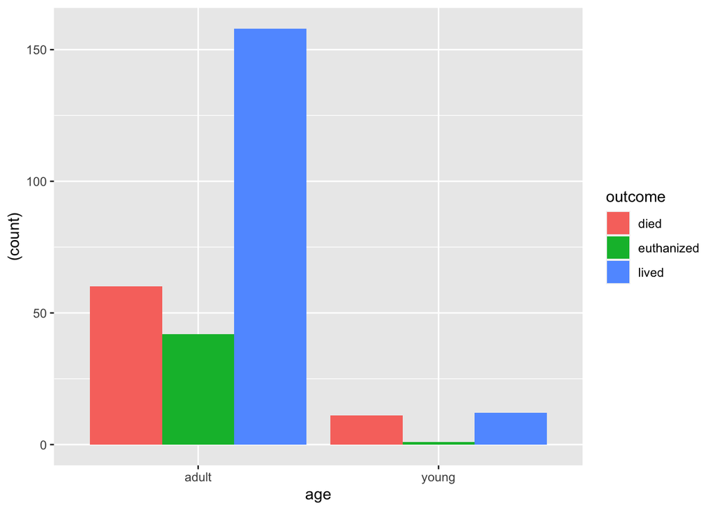

```r
library(ggplot2)
query2 <- "select distinct age,outcome, hospital_number from horse"
result2 <- dbGetQuery(con, query2)

ggplot(data=result2,aes(x=age,fill=outcome)) +
  geom_bar(aes(y=(..count..)),position=position_dodge())
```

```r
query2_1 <- "select age,outcome,count(*) cnt from horse group by age,outcome"
result2_1 <- dbGetQuery(con, query2_1)



knitr::kable(table(result2$age,result2$outcome))
```

|  | died | euthanized | lived |
| --- | --- | --- | --- |
| adult | 60 | 42 | 158 |
| young | 11 | 1 | 12 |

This graph shows number of horses by age groups and outcome which indicates horses’ life status. The number of young horses (24) is very small so that it might not be enought to talk about the pattern. The bar graph shows that adult horses have higher lived proportion than young horses.

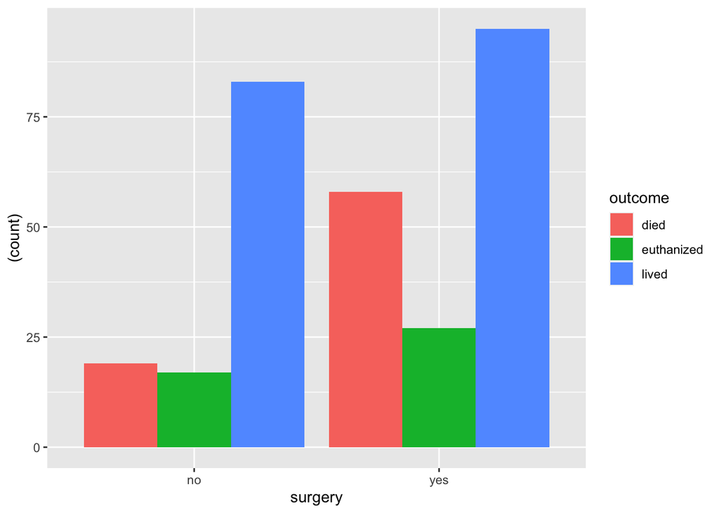

```r
query3 <- "select surgery,outcome from horse"
result3 <- dbGetQuery(con, query3)



ggplot(data=result3,aes(x=surgery,fill=outcome)) +
  geom_bar(aes(y=(..count..)),position=position_dodge())
```

The graph shows the outcome of horses, either died, lived, or euthanized based on whether a surgery treatment was applied. There are 119 observations for no surgery, and 180 for surgery. 70% of the horses without surgery survived. For horses who had surgery, around 53% lived, and 32% have died.

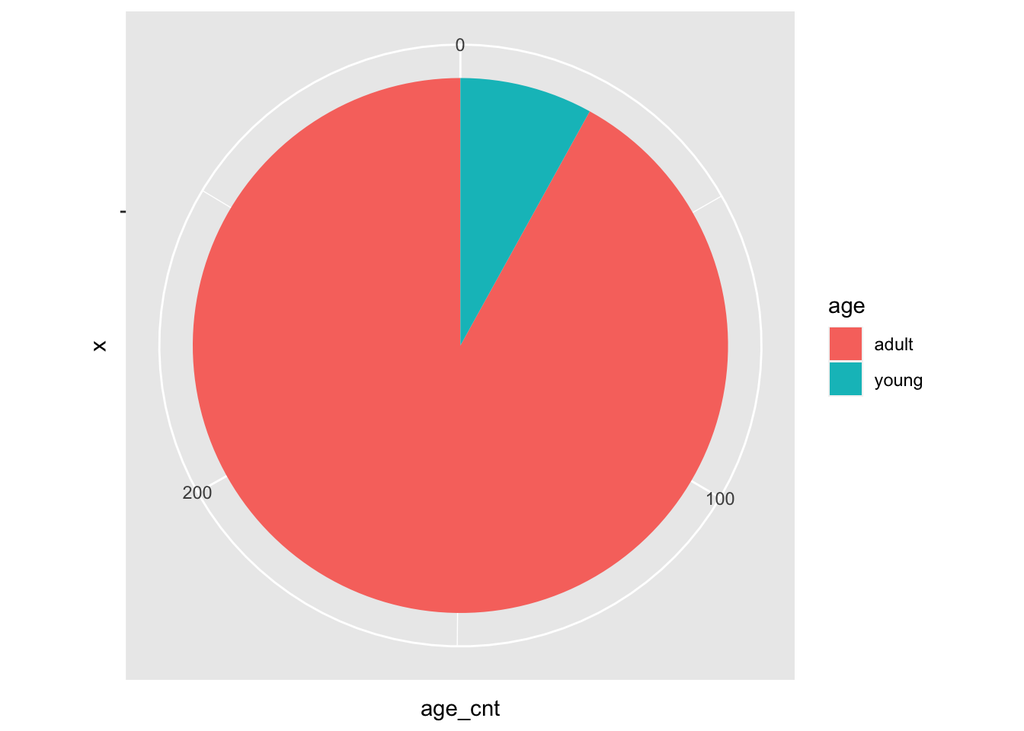

```r
query4_1 <- "select age,count(age) age_cnt from horse group by age"
result4_1 <- dbGetQuery(con, query4_1)



ggplot(result4_1,aes(x="",y=age_cnt,fill=age)) + geom_bar(stat="identity",width=1) +
  coord_polar("y",start=0)
```

```r
knitr::kable(result4_1)
```

| age | age_cnt |
| --- | --- |
| adult | 275 |
| young | 24 |

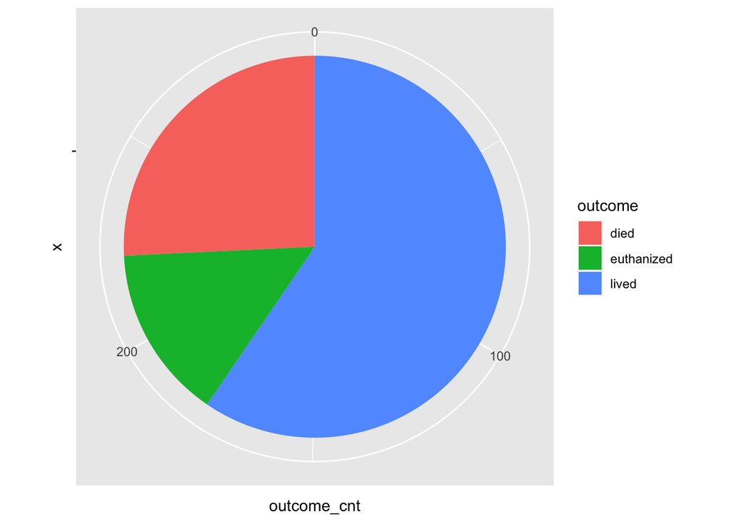

```r
query4_2 <- "select outcome,count(outcome) outcome_cnt from horse group by outcome"
result4_2 <- dbGetQuery(con, query4_2)
ggplot(result4_2,aes(x="",y=outcome_cnt,fill=outcome )) + geom_bar(stat="identity",width=1) +
  coord_polar("y",start=0)
```

```r
knitr::kable(result4_2)
```

| outcome | outcome_cnt |
| --- | --- |
| died | 77 |
| euthanized | 44 |
| lived | 178 |

```r
query5 <- "select outcome,surgical_lesion from horse"
result5 <- dbGetQuery(con, query5)

head(result5)
```

```
##      outcome surgical_lesion
## 1       died              no
## 2 euthanized              no
## 3      lived              no
## 4       died             yes
## 5       died              no
## 6      lived              no
```

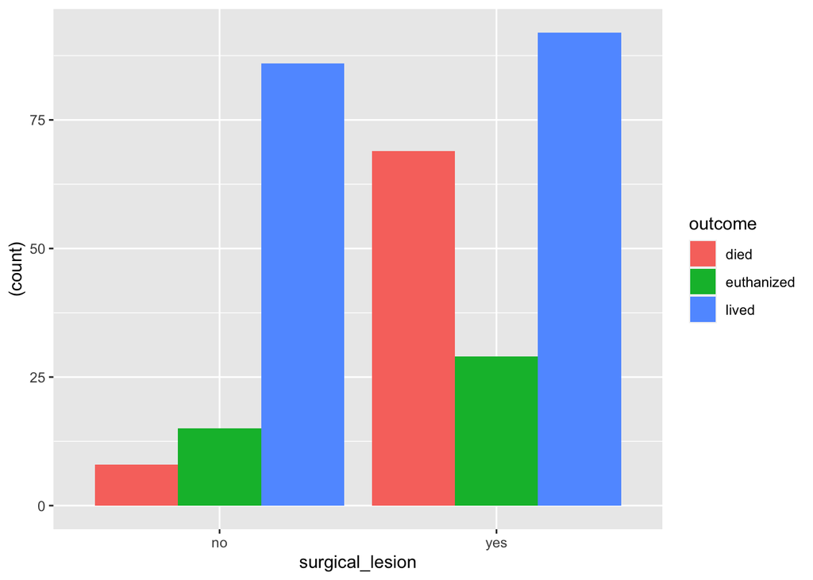

```r
ggplot(data=result5,aes(x=surgical_lesion,fill=outcome)) +
  geom_bar(aes(y=(..count..)),position=position_dodge())
```

```r
knitr::kable(table(result5$outcome,result5$surgical_lesion))
```

|  | no | yes |
| --- | --- | --- |
| died | 8 | 69 |
| euthanized | 15 | 29 |
| lived | 86 | 92 |

```r
query6 <- "select id,total_protein,outcome from horse"
result6 <- dbGetQuery(con, query6)

head(result6)
```

```
##   id total_protein    outcome
## 1  1           8.4       died
## 2  2          85.0 euthanized
## 3  3           6.7      lived
## 4  4           7.2       died
## 5  5           7.4       died
## 6  6            NA      lived
```

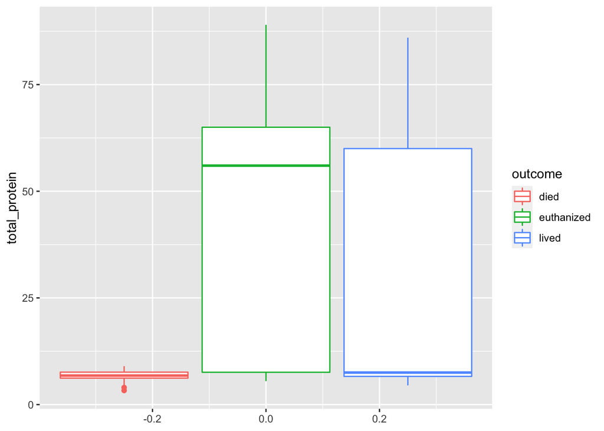

```r
result6$outcome<-as.factor(result6$outcome)
ggplot(data =result6, aes(y=total_protein,color=outcome)) +
  geom_boxplot(notch=F)
```

```r
#knitr::kable(result6$total_protein,result6$outcome)

library(dplyr)
```

```r
query6_1 <- "select outcome,avg(total_protein) mean_protein,STDDEV_SAMP(total_protein) sd, count(distinct id) horse_cnt from horse group by outcome"
result6_1 <- dbGetQuery(con, query6_1)


#Protein in the guts
# query6_2 <- "select id,abdomo_protein,outcome from horse"
# result6_2 <- dbGetQuery(con, query6_2)
#
# ggplot(data =result6_2, aes(y=abdomo_protein,color=outcome)) +
#   geom_boxplot(notch=F)

knitr::kable(as.data.frame(result6_1))
```

| outcome | mean_protein | sd | horse_cnt |
| --- | --- | --- | --- |
| died | 6.844615 | 1.177661 | 77 |
| euthanized | 42.038889 | 30.705228 | 44 |
| lived | 27.264848 | 28.452084 | 178 |

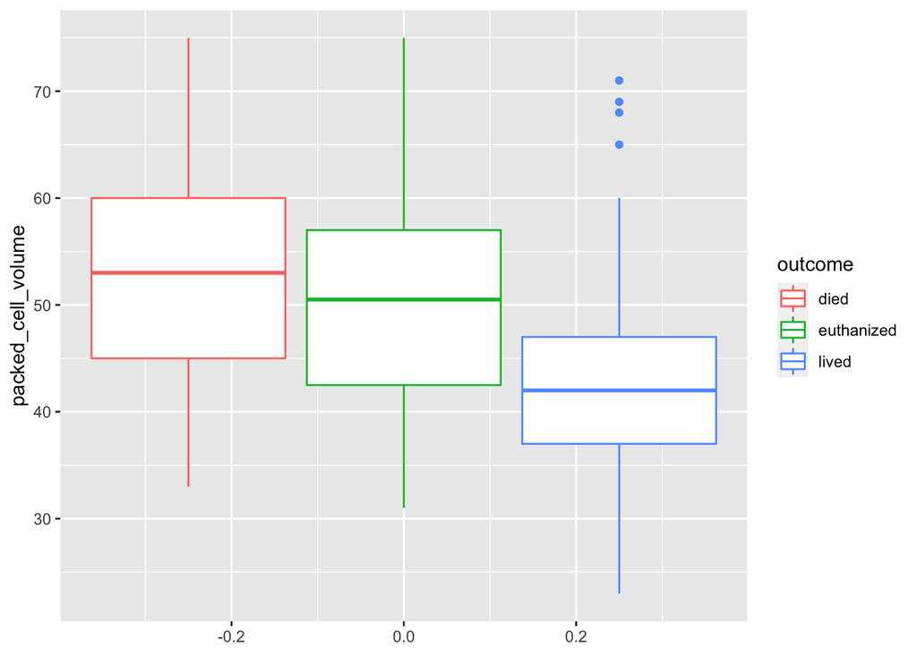

```r
query7 <- "select id,packed_cell_volume,outcome from horse"
result7 <- dbGetQuery(con, query7)

ggplot(data =result7, aes(y=packed_cell_volume,color=outcome)) +
  geom_boxplot()
```

```r
result7 %>% group_by(outcome) %>% summarize(mean = mean(packed_cell_volume,na.rm=T),
                                            sd = sd(packed_cell_volume,na.rm=T),
                                            count = length(packed_cell_volume))
```

```
## # A tibble: 3 x 4
##   outcome     mean    sd count
## * <chr>      <dbl> <dbl> <int>
## 1 died        52.5 11.4     77
## 2 euthanized  50.8 11.4     44
## 3 lived       42.7  7.97   178
```

```r
# Display two-way table for Pain and Outcome
library(pander)
query9 <- "SELECT * FROM db1.horse;"
result9 <- dbGetQuery(con, query9)
twoWay_Pain_Outcome <- pander(table(result9$pain, result9$outcome))
twoWay_Pain_Outcome
```

|  | died | euthanized | lived |
| --- | --- | --- | --- |
| **alert** | 2 | 1 | 35 |
| **depressed** | 14 | 12 | 33 |
| **extreme_pain** | 24 | 6 | 12 |
| **mild_pain** | 8 | 5 | 54 |
| **severe_pain** | 17 | 11 | 10 |

```r
# Display two-way table for abdominal distention and Outcome
query10 <- "SELECT * FROM db1.horse;"
result10 <- dbGetQuery(con, query10)
twoWay_abdominal_distention_Outcome <- pander(table(result10$abdominal_distention, result10$outcome))
twoWay_abdominal_distention_Outcome
```

|  | died | euthanized | lived |
| --- | --- | --- | --- |
| **moderate** | 27 | 12 | 26 |
| **none** | 7 | 7 | 61 |
| **severe** | 15 | 10 | 13 |
| **slight** | 14 | 4 | 47 |

```r
# Display two-way table for nasogastric reflux and Outcome
query11 <- "SELECT * FROM db1.horse;"
result11 <- dbGetQuery(con, query11)
twoWay_nasogastric_reflux_Outcome <- pander(table(result11$nasogastric_reflux, result10$outcome))
twoWay_nasogastric_reflux_Outcome
```

|  | died | euthanized | lived |
| --- | --- | --- | --- |
| **less_1_liter** | 14 | 5 | 16 |
| **more_1_liter** | 14 | 10 | 15 |
| **none** | 22 | 17 | 80 |

## Bibliography and References

Colic emergencies " large animal hospital " College of veterinary medicine " University of Florida. (n.d.). Retrieved May 28, 2021, from https://largeanimal.vethospitals.ufl.edu/hospital-services/surgery/colic/

Colic Surgery in Horses. (n.d.). Retrieved from https://www.acvs.org/surgical-procedures/colic-surgery-horses